# Getting Started in scRNA-seq

Author

CDN team

Published

Last compiled on 8 April, 2026

## Introduction

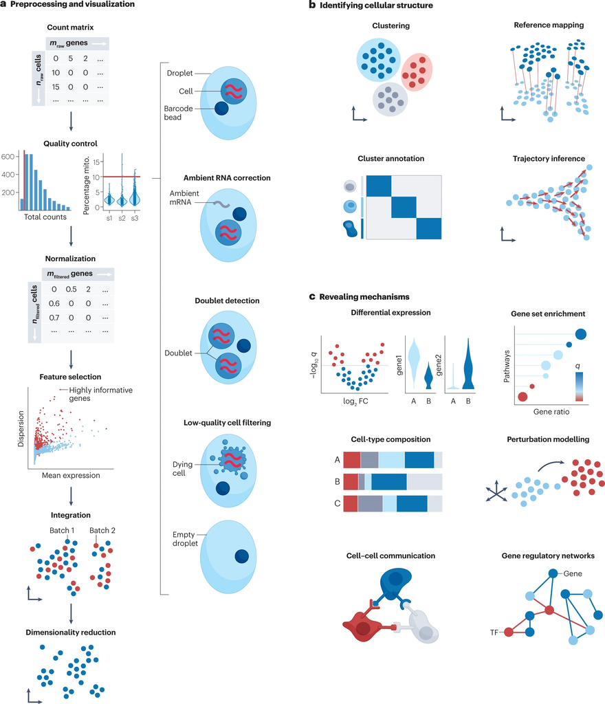

Heumos, L., Schaar, A.C., Lance, C. et al. Best practices for single-cell analysis across modalities. Nat Rev Genet 24, 550–572 (2023). https://doi.org/10.1038/s41576-023-00586-w

In this notebook, we’ll cover the following:

1. Load 10X data into a Seurat object
2. Quality Control
3. Preprocessing
   - Normalization
   - Highly variable feature selection
   - Dimensionality reduction
4. Integration
5. KNN and Clustering with Differentially Expressed Genes
6. Annotation

## Install & Load Libraries

```r
### Make sure all the packages are installed
# Required
if (!requireNamespace("Seurat", quietly = TRUE))
    install.packages("Seurat")
if (!requireNamespace("tidyverse", quietly = TRUE))
    install.packages("tidyverse")
if (!requireNamespace("ggplot2", quietly = TRUE))
    install.packages("ggplot2")

# Optional
if (!requireNamespace("harmony", quietly = TRUE))
    install.packages("harmony")
if (!requireNamespace("ggalluvial", quietly = TRUE))
    install.packages("ggalluvial")
```

```r
### Load all the necessary libraries
library(Seurat)
library(tidyverse)
library(ggplot2)
library(harmony)
library(ggalluvial)
```

### Download data

We’re going to be working with a dataset from 4 donors from 10X data.  
[Donor 1](https://www.10xgenomics.com/datasets/5k_Human_Donor1_PBMC_3p_gem-x) [Donor 2](https://www.10xgenomics.com/datasets/5k_Human_Donor2_PBMC_3p_gem-x) [Donor 3](https://www.10xgenomics.com/datasets/5k_Human_Donor3_PBMC_3p_gem-x) [Donor 4](https://www.10xgenomics.com/datasets/5k_Human_Donor4_PBMC_3p_gem-x)  
Please download the data from the 10X website or provided zip file into /data folder in your workshop directory.

NOTE: Before running this code, unzip the sample_filtered_feature_bc_matrix.gz files for each sample.

## 1 - Load data

```r
# getwd() output is /Users/rosehedderman/Desktop/CDN/BCRP_Beginner_1hr/
base_dir <- "/Users/rosehedderman/Desktop/CDN/BCRP_Beginner_1hr/data"
sample_dirs <- list.dirs(base_dir, recursive = FALSE)
valid_dirs <- sample_dirs[
  file.exists(file.path(sample_dirs, "sample_filtered_feature_bc_matrix"))
]

# Read 10X data
data_list <- lapply(valid_dirs, function(dir) {
  Read10X(data.dir = file.path(dir, "sample_filtered_feature_bc_matrix"))
})
names(data_list) <- basename(sample_dirs)

# Create Seurat Objects
seurat_list <- lapply(names(data_list), function(name) {
  CreateSeuratObject(counts = data_list[[name]], project = name)
})
names(seurat_list) <- names(data_list)

# Merge objects into one
se <- merge(
  x = seurat_list[[1]],
  y = seurat_list[-1],
  add.cell.ids = names(seurat_list)
)
se
```

Join counts layers into one using Seurat’s JoinLayers.

```r
se <- JoinLayers(se)
Layers(se)
```

```
[1] "counts"
```

Let’s peek at the metadata after loading.

```r
# dim(se@meta.data)
head(se@meta.data)
```

```
                                    orig.ident nCount_RNA nFeature_RNA
HealthyDonor1_AAACCAAAGGTGACGA-1 HealthyDonor1      42843         7089
HealthyDonor1_AAACCCTGTGACGAGT-1 HealthyDonor1       4896         2104
HealthyDonor1_AAACGAATCAGGCTAC-1 HealthyDonor1      12498         3564
HealthyDonor1_AAACGACAGATTGACT-1 HealthyDonor1      22198         4371
HealthyDonor1_AAACGATGTCTTGAAC-1 HealthyDonor1      10305         2945
HealthyDonor1_AAACGATGTGCGCGAA-1 HealthyDonor1      15949         4162
```

### Load Known Metadata

To add more metadata, we can join other dataframes to se@meta.data. Here, Donor 1 has automated cell type annotations that we can use as a reference.

```r
donor1_ct <- read_csv(paste0(base_dir, "/HealthyDonor1/cell_types/cell_types.csv"))
# head(donor1_ct)
```

Fix barcodes in cell_types dataframe to merge to Seurat object metadata.

```r
donor1_ct <- donor1_ct %>%
  mutate(barcode = paste0("HealthyDonor1_", barcode))
donor1_ct %>% tail(3)
```

```
# A tibble: 3 × 4
  barcode                          coarse_cell_type fine_cell_type             cell_count_in_model
  <chr>                            <chr>            <chr>                                    <dbl>
1 HealthyDonor1_TGTGTACGTCTGTGAT-1 T cell           CD4-positive helper T cell                 184
2 HealthyDonor1_TGTGTTAGTCAATCGT-1 T cell           mature T cell                              443
3 HealthyDonor1_TGTGTTGAGGATCTCA-1 T cell           mature T cell                              373
```

### Join Metadata

```r
se@meta.data <- se@meta.data %>%
  rownames_to_column("barcode") %>%
  rename(Donor = orig.ident) %>%
  left_join(donor1_ct, by = "barcode") %>%
  column_to_rownames("barcode")
# head(se@meta.data)
```

The table view is helpful for smaller scale, complete comparisons.

```r
table(se@meta.data$coarse_cell_type, se@meta.data$Donor)
```

```
                               HealthyDonor1 HealthyDonor2 HealthyDonor3 HealthyDonor4
  B cell                                 365             0             0             0
  glial cell                               2             0             0             0
  hematopoietic cell                      26             0             0             0
  hematopoietic precursor cell             3             0             0             0
  leukocyte                               47             0             0             0
  lymphocyte                             104             0             0             0
  macrophage                             173             0             0             0
  mast cell                                1             0             0             0
  monocyte                               951             0             0             0
  mononuclear cell                        48             0             0             0
  myeloid leukocyte                       20             0             0             0
  stem cell                                2             0             0             0
  T cell                                3968             0             0             0
```

### Data exploration

Mini Glossary:

- **Unique molecular identifier (UMI)**: unique molecular barcode added to each transcript before PCR amplification to correct for biases during that process.
- **Library size**: total number of UMIs detected for each cell.
- **Library complexity**: number of genes that have expression > 0 in each cell. The more genes detected in a cell the more complex a cell is. Examples of low complexity cells are platelets and red blood cells which can be confounded with low quality cells if not assessed properly.

The aim is to visualize the available data to catch potential library prep issues and batch effects.

#### Library Size

nCount_RNA is the number of UMIs per cell. This is a measure of the total number of transcripts detected in a cell and is the way to visualize library size.

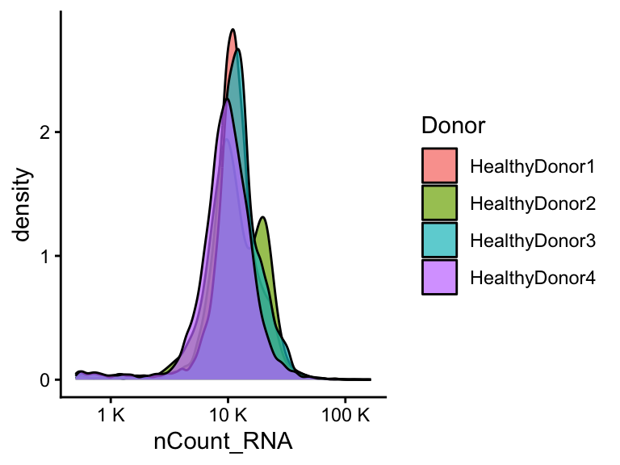

```r
# Visualize the UMI counts across samples.
ggplot(se@meta.data, aes(x = nCount_RNA, fill = Donor)) +
    geom_density(alpha = 0.7) + # color = "#6abcb6", fill = "#6abcb6",
    scale_x_continuous(
        transform = "log10",
        labels = scales::unit_format(unit = "K", scale = 1e-3)) +
    theme_classic()
```

#### Library Complexity

nFeature_RNA is the number of genes detected in a cell. Cells with few genes and few UMIs are considered low quality.

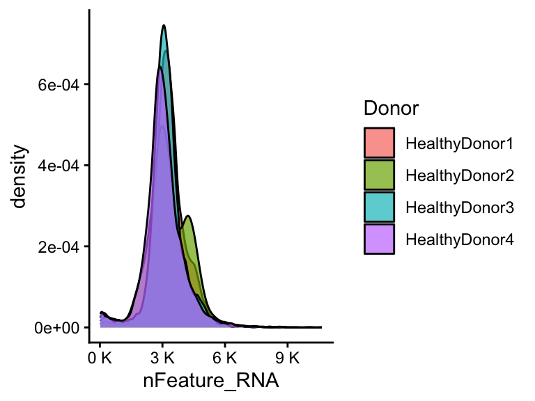

```r
# Visualize the feature (gene) counts across samples.
ggplot(se@meta.data, aes(x = nFeature_RNA, fill = Donor)) +
    geom_density(alpha = 0.7) + # color = "#6abcb6", fill = "#6abcb6",
    scale_x_continuous(
        labels = scales::unit_format(unit = "K", scale = 1e-3)) +
    theme_classic()
```

## 2 - Quality Control

QC is the process of filtering out “bad” data. This makes it a subjective process, making well-informed decisions is key to avoid removing biological signal. In this context, being conservative in what we call “poor quality” cells is best practice.

The main pitfall in this step is to be too stringent. This may lead to removing true biological signal. Some examples of cells that might be filtered out during the QC process are neutrophils, platelets, and erythrocytes since they have low library size and complexity.

Doublets can be confounded with transitioning cells or cells with mixed phenotypes. Therefore, it is very important that we are very careful when calling a cell a doublet! Otherwise, we might be removing very interesting biology.

Add percentage of common features

```r
# Calculate the percentage of mitochondrial genes
se <- PercentageFeatureSet(se, pattern = "^MT-", col.name = "perc.mt")
# Calculate the percentage of ribosomal genes
se <- PercentageFeatureSet(se, pattern = "^RPS|^RPL", col.name = "perc.ribo")
# Calculate the percentage of hemoglobin genes
se <- PercentageFeatureSet(se, pattern = "^HB[^(P)]", col.name = "perc.hb")
```

Visualize by sample

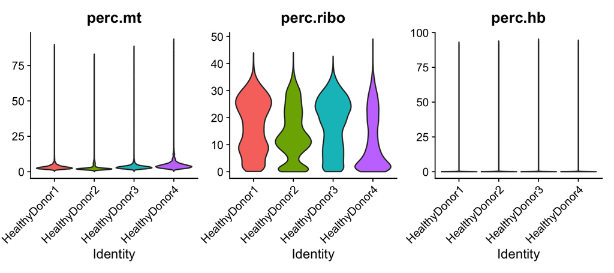

```r
# Plot features by Sample together
VlnPlot(se,
  group.by = "Donor",
  features = c("perc.mt", "perc.ribo", "perc.hb"),
  # log = TRUE,
  pt.size = 0
  ) &
    NoLegend()
```

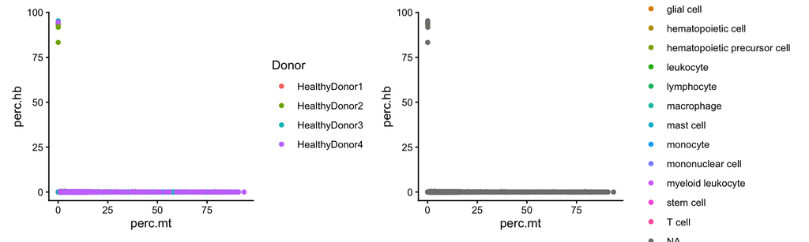

```r
# Comparison of mitochondrial and hemoglobin genes
p1 <- se@meta.data %>%
  ggplot(., aes(x = perc.mt, y = perc.hb, color = Donor)) +
    geom_point() +
    # scale_color_manual(values = pal) +
    theme_classic()
p2 <- se@meta.data %>%
  ggplot(., aes(x = perc.mt, y = perc.hb, color = `coarse_cell_type`)) +
    geom_point() +
    # scale_color_manual(values = donor_pal) +
    theme_classic()
p1 | p2
```

### Feature Covariation

Looking at how QC features covary between them gives us a better sense of what is going on and allows us to make better decisions.

This covariation plot colors by a specified variable in order to see its prevalence across the data.

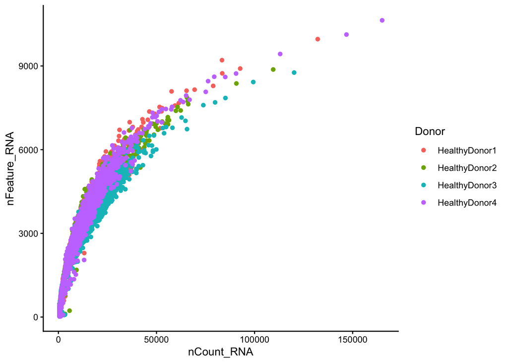

```r
# Plot by cell type
se@meta.data %>%
  ggplot(., aes(x = nCount_RNA, y = nFeature_RNA, color = Donor)) +
  geom_point() +
  theme_classic()
```

Use facet_wrap() in ggplot to separate your plots by a specified variable.

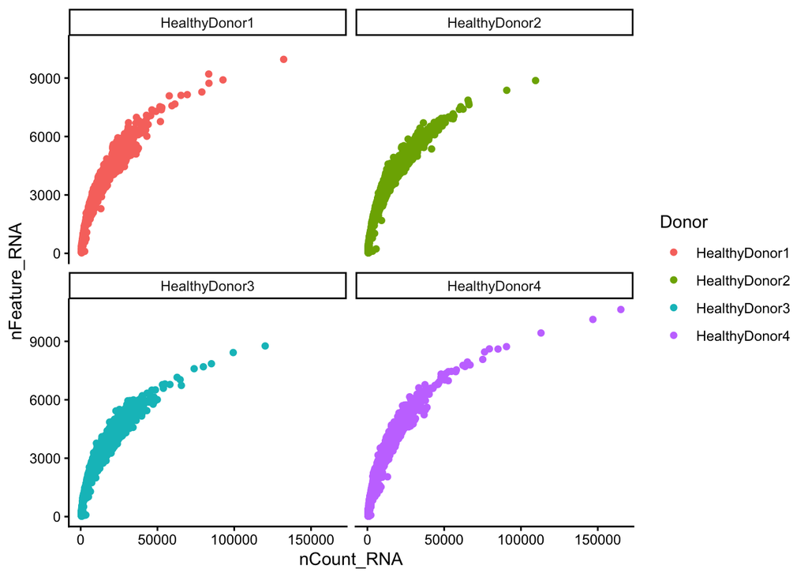

```r
# UMIs per sample
se@meta.data %>%
  ggplot(., aes(x = nCount_RNA, y = nFeature_RNA, color = Donor)) +
  geom_point() +
  facet_wrap(~Donor) +
  theme_classic()
```

Below, the distribution of mitochondrial percentage across the dataset is shown in relation to the library size and complexity.

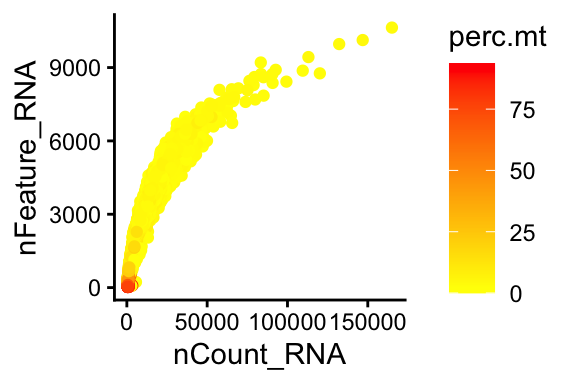

```r
# Percent Mitochondrial Genes
se@meta.data %>%
  ggplot(., aes(x = nCount_RNA, y = nFeature_RNA, color = perc.mt)) +
    geom_point() +
    theme_classic() +
    scale_color_gradient(low = "yellow", high = "red")
```

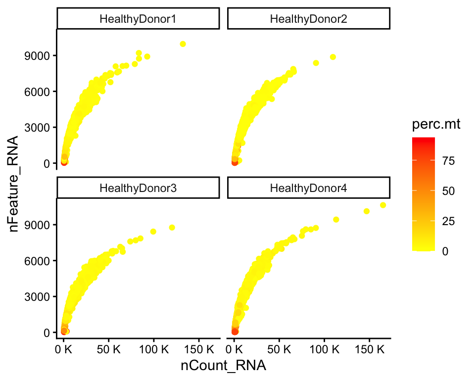

```r
# Percent MT Genes per sample
se@meta.data %>%
  ggplot(., aes(x = nCount_RNA, y = nFeature_RNA, color = perc.mt)) +
  geom_point() +
  facet_wrap(~`Donor`) +
  theme_classic() +
  scale_color_gradient(low = "yellow", high = "red") +
  scale_x_continuous(
        labels = scales::unit_format(unit = "K", scale = 1e-3))
```

### Doublets!

Doublet detection and removal is sensitive because you don’t want to remove any valuable outliers but still take into consideration the noisiness of the data.

`DoubletFinder` uses a nearest neighbor approach to identify doublets. The package has a function called `doubletFinder` that takes in a Seurat object and returns a Seurat object with doublet information added in the metadata.

**How it Works**

1. DoubletFinder combines random cell’s gene expression profiles to create “fake doublets.”
2. Artificial doublets are inserted into the data
3. Dimensionality reduction and a KNN graph is built with our cells and the fake doublets.
4. On the k-nearest neighbor graph each cell has k most-similar neighbors. pANN is the proportion of each cell’s neighbors that are “fake doublets”.
5. A high pANN value indicates that a larger proportion of the cells around a specific cell in the kNN graph are “fake doublets” suggesting that the cell has a transcriptome similar to a doublet.

Cells in transitioning states or cells with mixed phenotpyes can be mistaken for doublets. It is important not to disregard cells just because they have a large doublet score (pANN value), there might be interesting biological information in these cells!

`DoubletFinder` allows you to set a threshold and will give each cell a categorical result of ‘Singlet’ or ‘Doublet’. We suggest looking at the raw pANN values to understand the distribution of these cells and make threshold adjustments accordingly.

More information can be found in the CDN’s QC notebook or other public resources.

### Label cell quality

For the sake of preserving valuable data, we label low quality cells early on and filter them out later in the analysis.

```r
se@meta.data <- se@meta.data %>%
  mutate(
    quality = if_else(
        nFeature_RNA > 200 & nCount_RNA > 500 & perc.mt < 15, "good quality", "bad quality"),
    quality = factor(quality, levels = c("bad quality", "good quality"))
    )
```

# 3 - Preprocessing

1. Normalization
2. Highly Variable Gene Selection
3. Dimensionality Reduction

### A - Normalization

TOFIX: According to the documentation, this function does the following - Feature counts for each cell are divided by the total counts for that cell and multiplied by the scale.factor. This is then natural-log transformed using log1p.

```r
se@assays$RNA$counts[15:25, 15:30]
```

```
11 x 16 sparse Matrix of class "dgCMatrix"
```

```
ENSG00000235146 . . . . . . . . . . . . . . . .
OR4F16          . . . . . . . . . . . . . . . .
ENSG00000291215 . . . . . . . . . . . . . . . .
ENSG00000229905 . . . . . . . . . . . . . . . .
LINC01409       2 . . . . . 2 . 5 . . . . . . .
ENSG00000290784 . . 1 . . . . . . . . . . . . .
FAM87B          . . . . . . . . . . . . . . . .
LINC00115       . . . . . . . . . . . 1 . . . .
LINC01128       . . . . . . . . . . . . . . . .
ENSG00000288531 . . . . . . . . . . . . . . . .
FAM41C          . . . . . . . . . . . . . . . .
```

```r
se <- NormalizeData(se, normalization.method = "LogNormalize", scale.factor = 1e4)

se@assays$RNA$data[15:25, 15:30]
```

```
11 x 16 sparse Matrix of class "dgCMatrix"
```

```
ENSG00000235146 .         . .        . . . .         . .        . . .         . . . .
OR4F16          .         . .        . . . .         . .        . . .         . . . .
ENSG00000291215 .         . .        . . . .         . .        . . .         . . . .
ENSG00000229905 .         . .        . . . .         . .        . . .         . . . .
LINC01409       0.7317941 . .        . . . 0.5623725 . 1.758706 . . .         . . . .
ENSG00000290784 .         . 0.694249 . . . .         . .        . . .         . . . .
FAM87B          .         . .        . . . .         . .        . . .         . . . .
LINC00115       .         . .        . . . .         . .        . . 0.5392645 . . . .
LINC01128       .         . .        . . . .         . .        . . .         . . . .
ENSG00000288531 .         . .        . . . .         . .        . . .         . . . .
FAM41C          .         . .        . . . .         . .        . . .         . . . .
```

### B - Highly Variable Gene Selection

TOFIX: Subsetting our count matrix to highly variable genes is a key step for downstream analysis. We need to reduce the dimensions of the count matrix so that we can carry out downstream tasks such as PCA.

The intutition behind selecting HVG is that those genes with highest variability capture high level biological variability in our datasets and can help us identify the populations present in our dataset.

To do this we can use the vst method: - First, fits a line to the relationship of log(variance) and log(mean) using local polynomial regression (loess). - Then standardizes the feature values using the observed mean and expected variance (given by the fitted line). - Feature variance is then calculated on the standardized values after clipping to a maximum (see clip.max parameter).

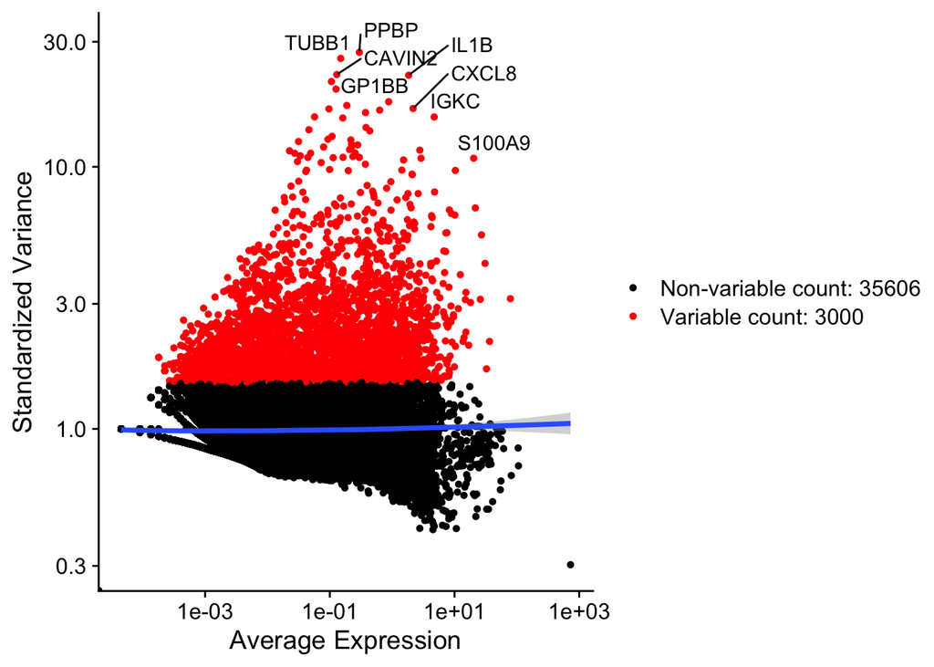

```r
se <- FindVariableFeatures(se, nfeatures = 3000, selection.method = "vst")

# Identify the 50 most highly variable genes
top <- head(VariableFeatures(se), 100)

# plot variable features with and without labels
plot1 <- VariableFeaturePlot(se)
plot2 <- LabelPoints(plot = plot1, points = top, repel = TRUE)
plot2 +
    geom_smooth(method = "loess", error = FALSE) +
    scale_y_log10()
```

### C - Dimensionality Reduction

Mini Glossary:

- **Dimensionality Reduction**: The computational process of reducing a large data matrix to fewer features.
- **Latent Space/Embeddings**: A latent space is a hidden set of dimensions in the data that could be useful in ways the raw data is not.
- **Feature**: A variable in a sample x variable matrix. In a cell x gene matrix, the gene is the feature. In PCA, the principal components are the features.
- **Loadings**: This is the term used to describe the feature translation matrix. Which genes are in which PC? The Loadings matrix shows the weights of each gene in each PC.

```r
se <- se  %>%
    ScaleData(verbose = FALSE, features = VariableFeatures(.)) %>%
    RunPCA(
        npcs = 30,
        ndims.print = 1:5,
        nfeatures.print = 10
    )

# This is where latent spaces, aka dimensional reductions are stored. If we call it directly, we can see some information about the PCA.
se@reductions$pca
```

```
A dimensional reduction object with key PC_
 Number of dimensions: 30
 Number of cells: 22203
 Projected dimensional reduction calculated:  FALSE
 Jackstraw run: FALSE
 Computed using assay: RNA
```

#### Using PCA to understand variance in your data

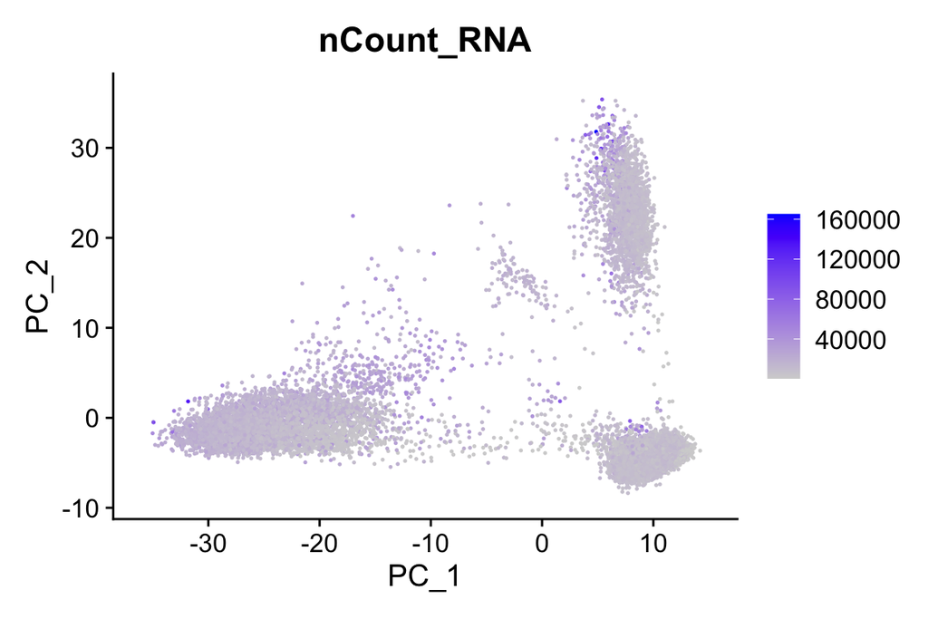

```r
FeaturePlot(
    se,
    reduction = "pca",
    features = 'nCount_RNA'
    )
```

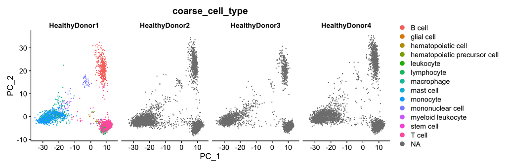

```r
DimPlot(
    se,
    reduction = "pca",
    group.by = 'coarse_cell_type',
    split.by = "Donor" # ,
    # dims = c(2,3)
    )
```

```r
# DT::datatable(se@reductions$pca@cell.embeddings)
```

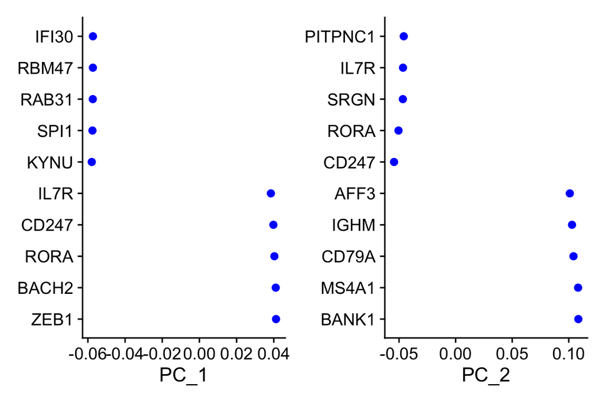

```r
VizDimLoadings(
    se,
    dims = 1:2,
    reduction = "pca",
    nfeatures =10,
    # ncol = 3,
    # By balanced = TRUE, we see top loadings in each direction of each PC
    balanced = TRUE)
```

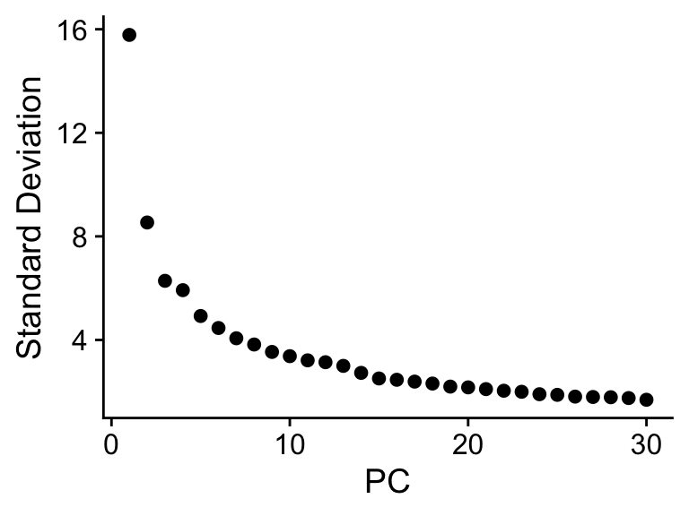

```r
ElbowPlot(se, ndims = 50)
```

# 4 - INTEGRATION

```r
se <- se %>%
  RunUMAP(
    dims = 1:20,
    reduction = "pca",
    reduction.name = "pca_umap",
    verbose = FALSE
  ) %>%
    RunHarmony(
      group.by.vars = 'Donor',
      reduction.uptest = 'pca',
    ) %>%
  RunUMAP(
    dims = 1:20,
    reduction = "harmony",
    reduction.name = "harmony_umap",
    verbose = FALSE
  )
```

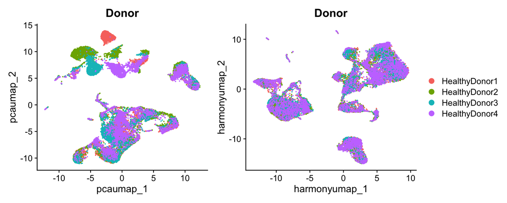

```r
DimPlot(se,
        reduction = "pca_umap",
        group.by = "Donor") +
  theme(legend.position = "none") +
  DimPlot(se,
        reduction = "harmony_umap",
        group.by = "Donor") +
  theme(legend.position = "none")
```

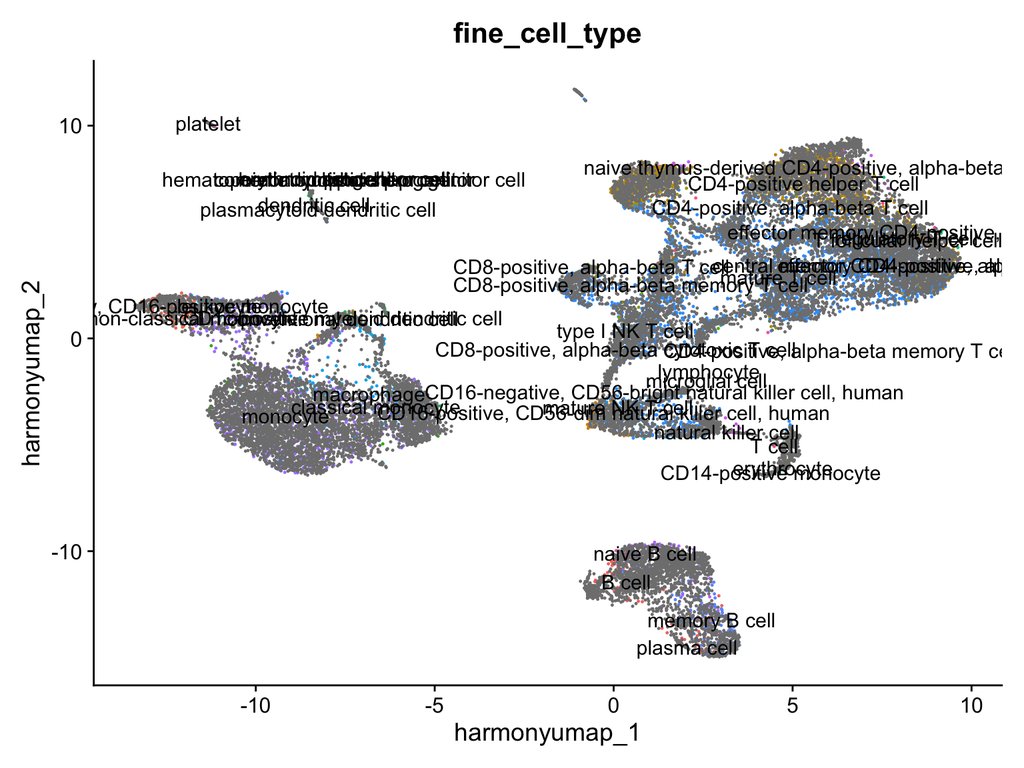

```r
DimPlot(se,
        reduction = "harmony_umap",
        group.by = "fine_cell_type",
        label = TRUE) + NoLegend()
```

Compare clustering of good and bad quality cells.

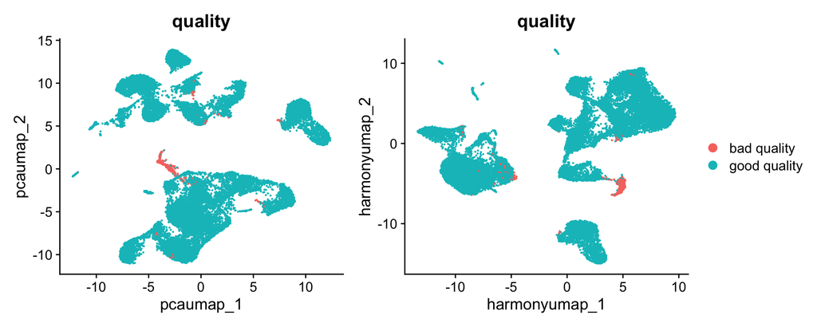

```r
DimPlot(se,
        reduction = "pca_umap",
        group.by = "quality") +
  theme(legend.position = "none") +
  DimPlot(se,
        reduction = "harmony_umap",
        group.by = "quality") +
  theme(legend.position = "none")
```

# 5 - KNN and Clustering with Differentially Expressed Genes

```r
se <- se %>%
    FindNeighbors(
        reduction = "harmony",
        dims = 1:20,
        k.param = 20,
        verbose = FALSE
    )
```

```r
# Look at the k-nearest neighbors (nn) and shared nearest neighbors (snn) graphs computed
se@graphs
```

```
$RNA_nn
A Graph object containing 22203 cells
$RNA_snn
A Graph object containing 22203 cells
```

```r
se <- FindClusters(
      object = se,
      resolution = c(0.01, 0.05, 0.1, 0.15, 0.2),
      algorithm = 1,
      verbose = FALSE)
```

Visualize Clusters

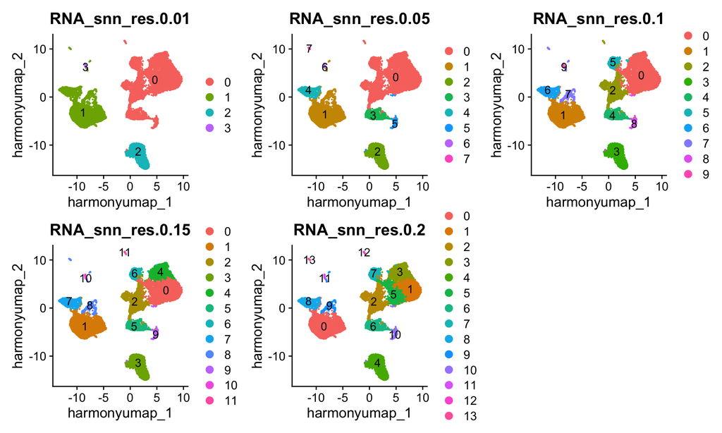

```r
DimPlot(
    se,
    reduction = "harmony_umap", # "pca_umap"
    group.by = c(
        "RNA_snn_res.0.01", "RNA_snn_res.0.05",
        "RNA_snn_res.0.1", "RNA_snn_res.0.15",
        "RNA_snn_res.0.2"),
    label = TRUE
)
```

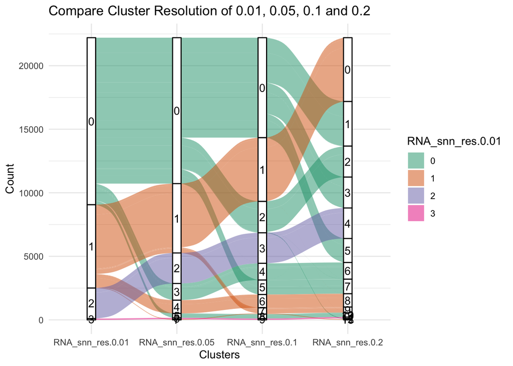

```r
# install.packages("ggalluvial")
library(ggalluvial)
se@meta.data %>%
    dplyr::count(
        coarse_cell_type, RNA_snn_res.0.01, RNA_snn_res.0.05,
        RNA_snn_res.0.1, RNA_snn_res.0.2) %>%
    ggplot(
        aes(axis1 = RNA_snn_res.0.01, axis2 = RNA_snn_res.0.05,
            axis3 = RNA_snn_res.0.1, axis4 = RNA_snn_res.0.2,
            y = n)) +
    geom_alluvium(aes(fill = RNA_snn_res.0.01), width = 0.1) +
    geom_stratum(width = 0.1) +
    geom_text(stat = "stratum", aes(label = after_stat(stratum))) +
    scale_x_discrete(
        limits = c("RNA_snn_res.0.01", "RNA_snn_res.0.05",
                   "RNA_snn_res.0.1", "RNA_snn_res.0.2"),
        expand = c(0.15, 0.05)) +
    scale_fill_brewer(palette = "Dark2") +
    labs(title = "Compare Cluster Resolution of 0.01, 0.05, 0.1 and 0.2",
         x = "Clusters",
         y = "Count") +
    theme_minimal()
```

### Differential Gene Expression via Wilcoxon

```r
Idents(se) <- se$RNA_snn_res.0.05
mgs <- FindAllMarkers(
    se,
    test.use = "wilcox",
    slot = "data",
    only.pos = TRUE,
    logfc.threshold = 0.5,
    min.pct = 0.25)
# write_csv(mgs, paste0(data_dir, "/marker_genes_res_005.csv))
```

```r
DT::datatable(mgs, filter = "top")
```

|  | p_val | avg_log2FC | pct.1 | pct.2 | p_val_adj | cluster | gene |
| --- | --- | --- | --- | --- | --- | --- | --- |
| BCL11B | 0 | 4.220921658265552 | 0.965 | 0.091 | 0 | 0 | BCL11B |
| IL7R | 0 | 5.718314314305989 | 0.898 | 0.049 | 0 | 0 | IL7R |
| CAMK4 | 0 | 5.123852925055571 | 0.898 | 0.059 | 0 | 0 | CAMK4 |
| CD247 | 0 | 0.8510940430767917 | 0.96 | 0.169 | 0 | 0 | CD247 |
| CD6 | 0 | 4.562436485569849 | 0.845 | 0.061 | 0 | 0 | CD6 |
| ITK | 0 | 2.796200551275117 | 0.91 | 0.133 | 0 | 0 | ITK |
| CD2 | 0 | 4.338245498734317 | 0.849 | 0.082 | 0 | 0 | CD2 |
| CD3E | 0 | 4.192396722869592 | 0.836 | 0.069 | 0 | 0 | CD3E |
| TC2N | 0 | 3.869807248108871 | 0.841 | 0.12 | 0 | 0 | TC2N |
| CD3D | 0 | 6.001186132623881 | 0.743 | 0.026 | 0 | 0 | CD3D |

[output cut: 10968 more lines]

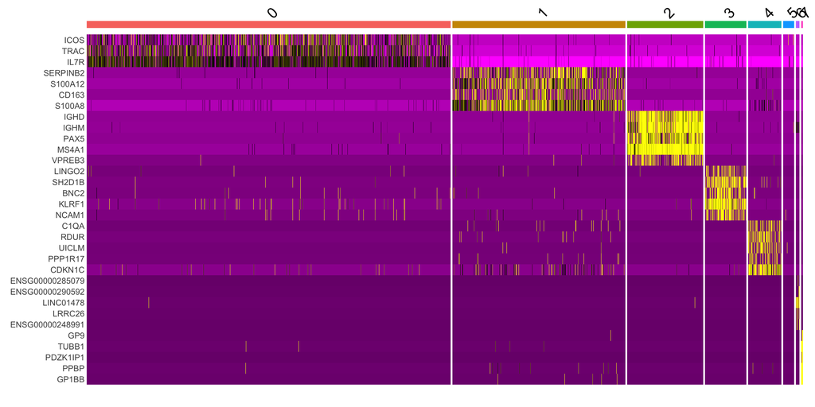

```r
top10 <- mgs %>%
    arrange(cluster, desc(avg_log2FC)) %>%
    group_by(cluster) %>%
    dplyr::filter(avg_log2FC > 1) %>%
    slice_head(n = 5) %>%
    ungroup()

DoHeatmap(se, features = top10$gene) + NoLegend()
```

P-Value Interpretation in OSCA(https://bioconductor.org/books/3.17/OSCA.advanced/marker-detection-redux.html#p-value-invalidity)

# 6 - Annotation

1 - Manual Annotation  
2 - Automatic Annotation (Useful as a reference but depends on the breadth/depth/strength of the original.)

### Common Cell Type Gene Markers

```r
markers <- c(
  # Leukocyte
  "PTPRC",
  # T Cells
  "CD3D", "CD3E", "CD4", "CD8A", "CD8B",
  # B Cells
  "MS4A1", "CD79A",
  # NK Cells
  "FCGR3A", "CD14",
  # Macrophage
  "CD68",
  # Monocyte
  "LYZ", "LST1", "FCN1",
  # pDCs
  "JCHAIN", "CLEC4C",
  # Platelets
  "PF4", "CD41", "PPBP",
  # Proliferating
  "MKI67", "PCNA"
)
```

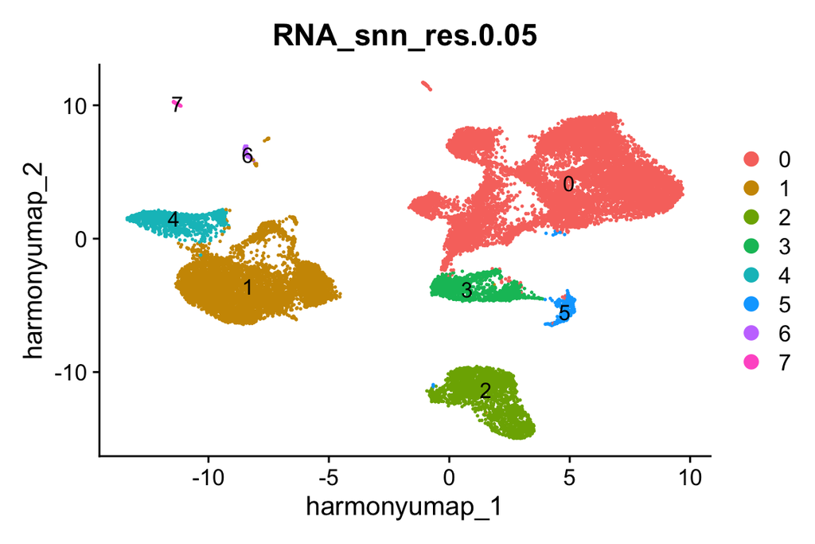

```r
DimPlot(
    se,
    reduction = "harmony_umap",
    group.by = "RNA_snn_res.0.05",
    label = TRUE
)
```

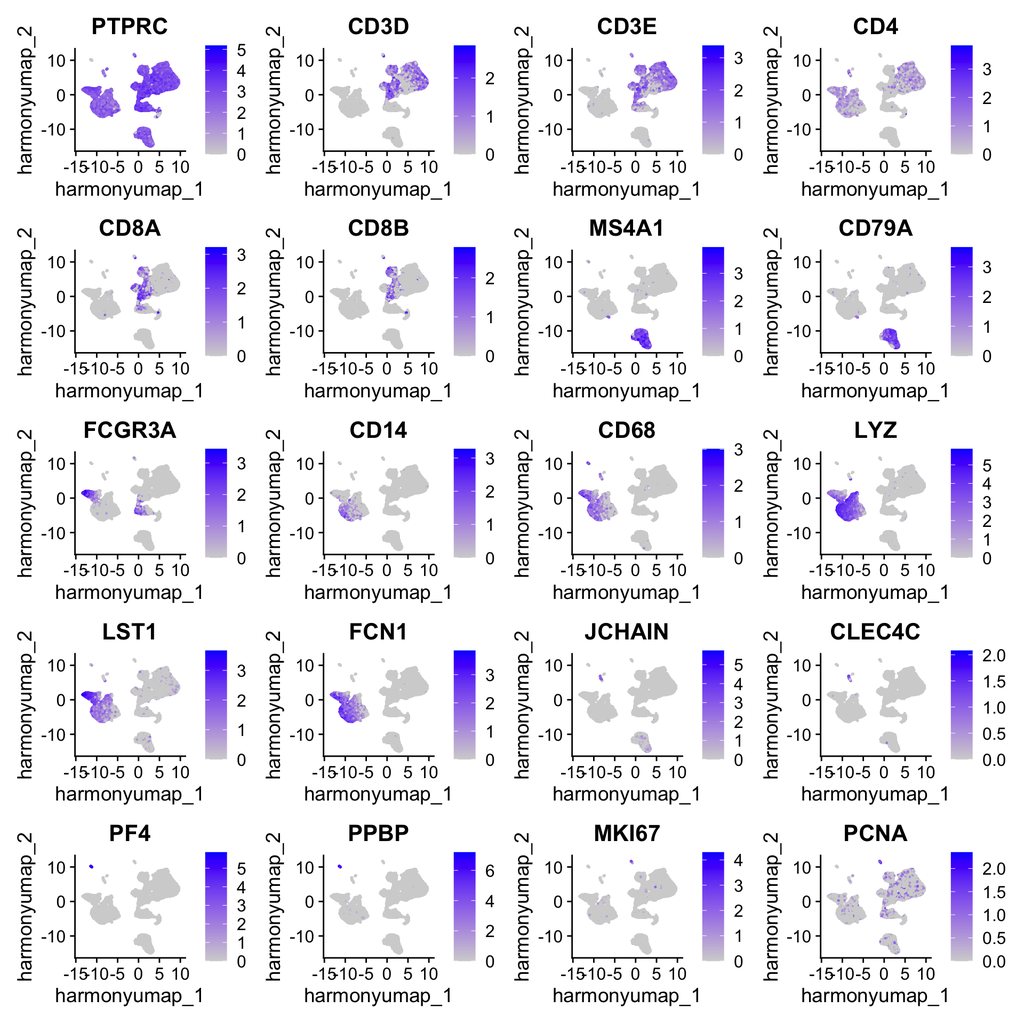

```r
FeaturePlot(
  se,
  reduction = "harmony_umap",
  features = markers
)
```

Violin Plot of Annotation markers

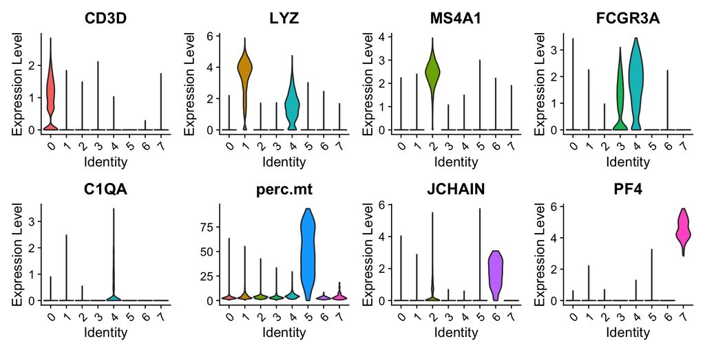

```r
VlnPlot(se,
        # C1QA non-classical monocytes
        features = c("CD3D", "LYZ","MS4A1", "FCGR3A", "C1QA", "perc.mt", "JCHAIN", "PF4"),
        ncol = 4,
        pt.size = 0)
```

Assign Annotations

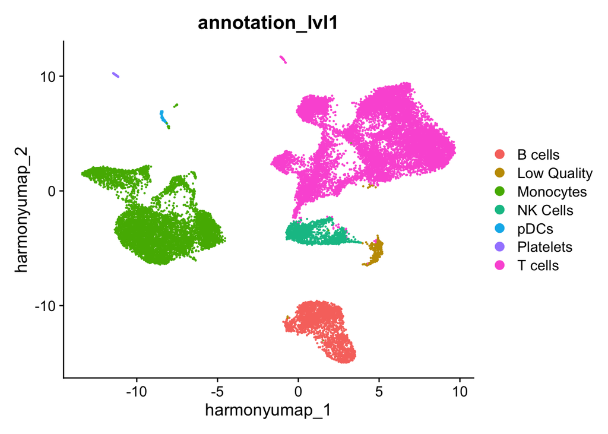

```r
se@meta.data <- se@meta.data %>%
  dplyr::mutate(
    annotation_lvl1 = dplyr::case_when(
      RNA_snn_res.0.05 == 0 ~ "T cells",
      RNA_snn_res.0.05 == 1 ~ "Monocytes",
      RNA_snn_res.0.05 == 2 ~ "B cells",
      RNA_snn_res.0.05 == 3 ~ "NK Cells",
      RNA_snn_res.0.05 == 4 ~ "Monocytes",
      RNA_snn_res.0.05 == 5 ~ "Low Quality",
      RNA_snn_res.0.05 == 6 ~ "pDCs",
      RNA_snn_res.0.05 == 7 ~ "Platelets"
      )
  )

DimPlot(se, group.by = "annotation_lvl1", reduction = "harmony_umap")
```

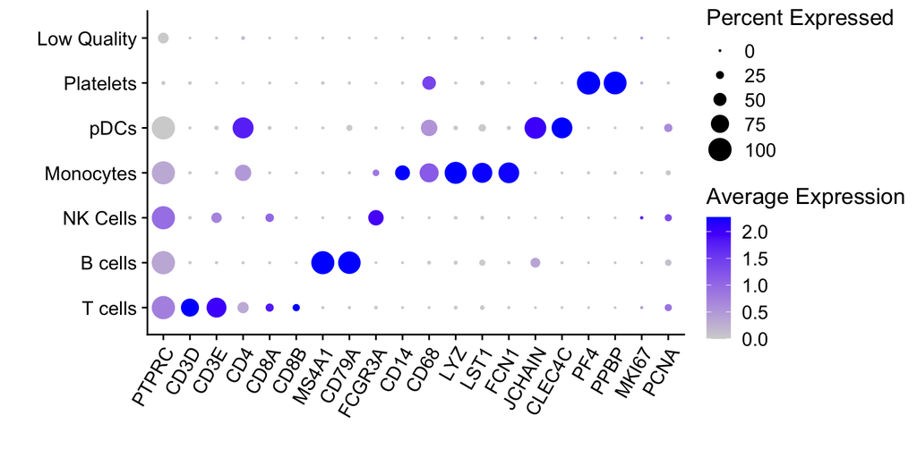

```r
order <- c("T cells", "B cells", "NK Cells", "Monocytes", "pDCs", "Platelets", "Low Quality")

se$annotation_lvl1_ord <- factor(
  x = se$annotation_lvl1,
  levels = order)

Seurat::DotPlot(
  object = se,
  features = markers,
  group.by = "annotation_lvl1_ord",
  col.min = 0,
  dot.min = 0) +
  ggplot2::scale_x_discrete(
    breaks = markers) +
  ggplot2::theme(axis.text.x = ggplot2::element_text(angle = 60, hjust = 1)) +
  ggplot2::labs(x = "", y = "")
```

```r
table(se@meta.data$coarse_cell_type, se@meta.data$annotation_lvl1)
```

```
                               B cells Low Quality Monocytes NK Cells pDCs Platelets T cells
  B cell                           364           0         0        0    0         0       1
  glial cell                         0           0         0        1    0         0       1
  hematopoietic cell                 0           9         0        0    0        17       0
  hematopoietic precursor cell       0           0         3        0    0         0       0
  leukocyte                          0           0        33       14    0         0       0
  lymphocyte                         0           0         0       93    0         0      11
  macrophage                         0           0       173        0    0         0       0
  mast cell                          0           0         1        0    0         0       0
  monocyte                           0           6       945        0    0         0       0
  mononuclear cell                   0           0        15        0   33         0       0
  myeloid leukocyte                  0           0        20        0    0         0       0
  stem cell                          0           0         2        0    0         0       0
  T cell                            14          29        13      277    1         0    3634
```

# Save Whole Object

```r
save_dir <- paste0(base_dir, "/annot_lvl1.rds")
saveRDS(subset(se, subset = quality == "good quality"), save_dir)
```

### Split Object into Sub Types

```r
lymphocyte <- subset(se, subset = annotation_lvl1 %in% c("T Cells", "B Cells", "NK Cells"))
# save lymphocyte object
lymph_dir <- paste0(base_dir, "/annot_lvl1_lymphocyte.rds")
saveRDS(lymphocyte, lymph_dir)
```

```r
myeloid <- subset(se, subset = annotation_lvl1 %in% c("Monocytes","pDCs"))
# save lymphocyte object
myeloid_dir <- paste0(base_dir, "/annot_lvl1_myeloid.rds")
saveRDS(myeloid, myeloid_dir)
```